# Crime Data Analysis & Predictive Modeling

Rasha Quadri

2026-03-26

# **Overview**

This project analyzes crime data from Los Angeles to:

- Examine trends in crime over time
- Identify which victim groups are most affected
- Build a predictive model for arrest outcomes

The analysis follows a full data science workflow including data cleaning, exploratory data analyis, statistical modeling and model evaluation.

- Note: The dataset contains missing values and categorical inconsistencies that require preprocessing.

# **1- Data Loading & Cleaning**

### **Loading Libraries**

```r
library(ggplot2)
library(dplyr)
library(caret)
```

### **Loading Data**

```r
LA_crime <- read.csv(unzip("Crime_Data_from_2020_to_Present.csv.zip",
                           "Crime_Data_from_2020_to_Present.csv"))

# Sample 50,000 rows for computational efficiency
set.seed(123)
LA_crime <- LA_crime[sample(nrow(LA_crime),50000), ]
```

### **Data Cleaning & Handling Missing Values**

```r
LA_crime$DATE.OCC <- as.Date(LA_crime$DATE.OCC, format = "%m/%d/%Y")

LA_crime$Year <- format(LA_crime$DATE.OCC, "%Y")

LA_crime$Vict.Descent[LA_crime$Vict.Descent == ""] <- NA
LA_crime$Vict.Sex[LA_crime$Vict.Sex == ""] <- NA

LA_crime$Vict.Sex <- as.factor(LA_crime$Vict.Sex)
LA_crime$Vict.Descent <- as.factor(LA_crime$Vict.Descent)
LA_crime$Status <- as.factor(LA_crime$Status)
LA_crime$AREA.NAME <- as.factor(LA_crime$AREA.NAME)
LA_crime$Crm.Cd.Desc <- as.factor(LA_crime$Crm.Cd.Desc)


is.na(LA_crime)
```

[output not shown]

[output cut: 13782 more lines]

```r
LA_crime_model <- LA_crime %>%
  select(Vict.Age, Vict.Sex, Vict.Descent, AREA.NAME, Crm.Cd.Desc, Status, Year)


LA_crime_model <- na.omit(LA_crime_model)
```

The data was cleaned by:

- Converting date fields into proper formats
- Extracting the year for time-based analysis
- Handling missing values by removing incomplete observations
- Converting categorical variables into factors for modeling

# **2- Exploratory Data Analysis**

### **a) Crime trend over years**

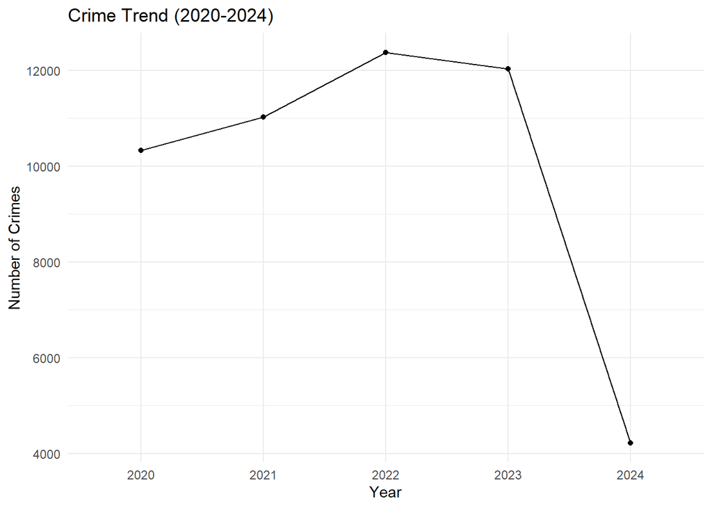

```r
crime_year <- LA_crime %>%
  count(Year)

ggplot(crime_year, aes(x=Year, y=n, group=1))+
  geom_line()+
  geom_point()+
  labs(title = "Crime Trend (2020-2024)",
       x="Year",
       y="Number of Crimes")+
  theme_minimal()
```

Crime counts increase steadily from 2021 to 2022, followed by a slight decline. The sharp drop observed in the most recent year is likely due to incomplete data rather than a true decrease in crime.

### **b) Victim ethnicity distribution**

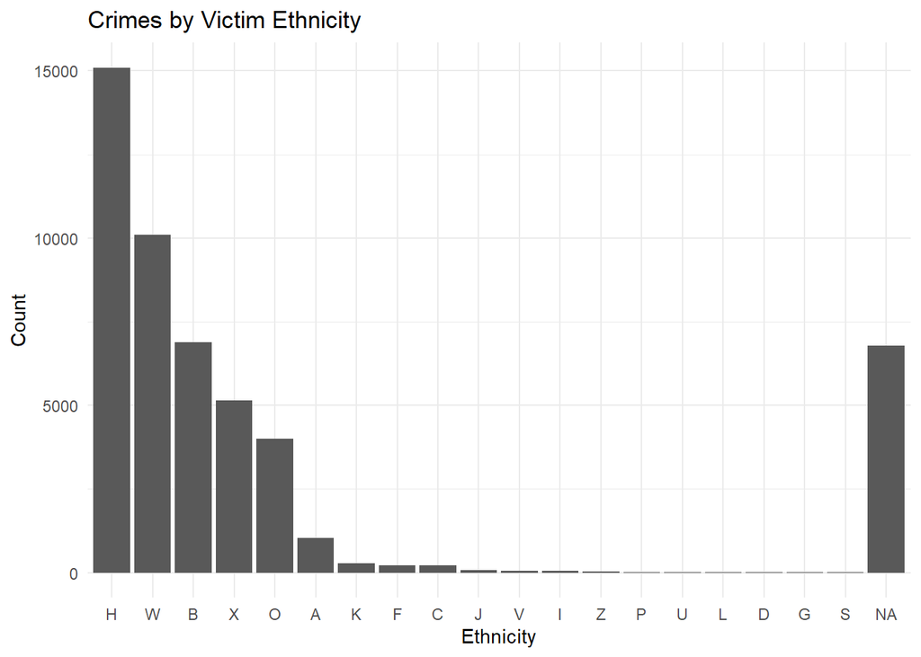

```r
victim_eth <- LA_crime %>%
  count(Vict.Descent) %>%
  arrange(desc(n))


ggplot(victim_eth, aes(x=reorder(Vict.Descent, -n), y=n))+
  geom_bar(stat="identity")+
  labs(title="Crimes by Victim Ethnicity",
       x = "Ethnicity",
       y = "Count")+
  theme_minimal()
```

Certain victim groups show higher recorded crime counts. However, these differences may reflect population distribution, reporting patterns, or data collection biases rather than true risk levels.

# **Predictive Modeling: Arrest Outcomes**

To predict whether a crime results in an arrest, a binary target variable was created from the case status. The dataset was then split into training and testing sets for model evaluation.

```r
table(LA_crime_model$Status)
```

```
##
##    AA    AO    IC    JA    JO
##  4059  5359 33563   153    81
```

```r
LA_crime_model$Arrest <- ifelse(LA_crime_model$Status %in% c("AA","JA"),1,0)
LA_crime_model$Arrest <- as.factor(LA_crime_model$Arrest)
```

```r
# Train/Test Split

set.seed(123)
train_index <- sample(1:nrow(LA_crime_model), 0.8*nrow(LA_crime_model))

train <- LA_crime_model[train_index, ]
test <- LA_crime_model[-train_index, ]
```

```r
# Logistic Regression Model

model <- glm(Arrest ~ Vict.Age + Vict.Sex + Vict.Descent + AREA.NAME,
             data = train,
             family = "binomial")

summary(model)
```

```
##
## Call:
## glm(formula = Arrest ~ Vict.Age + Vict.Sex + Vict.Descent + AREA.NAME,
##     family = "binomial", data = train)
##
## Coefficients:
##                        Estimate Std. Error z value Pr(>|z|)
## (Intercept)           -1.929660   0.159540 -12.095  < 2e-16 ***
## Vict.Age              -0.011595   0.001157 -10.022  < 2e-16 ***
## Vict.SexM             -0.150283   0.039953  -3.761 0.000169 ***
## Vict.SexX             -0.217818   0.166987  -1.304 0.192098
## Vict.DescentB          0.156007   0.141364   1.104 0.269772
## Vict.DescentC         -2.613221   1.011850  -2.583 0.009805 **
## Vict.DescentD        -11.855788 623.370112  -0.019 0.984826
## Vict.DescentF         -2.059773   0.723518  -2.847 0.004415 **
## Vict.DescentG          1.715896   1.261088   1.361 0.173625
## Vict.DescentH          0.362478   0.135570   2.674 0.007501 **
## Vict.DescentI        -12.084319 147.933003  -0.082 0.934895
## Vict.DescentJ         -1.516796   1.018054  -1.490 0.136251
## Vict.DescentK         -0.474690   0.350586  -1.354 0.175740
## Vict.DescentL        -12.040854 508.552159  -0.024 0.981110
## Vict.DescentO         -0.039248   0.147143  -0.267 0.789673
## Vict.DescentP        -12.140694 212.786533  -0.057 0.954501
## Vict.DescentS        -12.398235 882.743389  -0.014 0.988794
## Vict.DescentU          0.479952   1.097489   0.437 0.661880
## Vict.DescentV         -1.077972   1.023242  -1.053 0.292118
## Vict.DescentW         -0.024170   0.138648  -0.174 0.861608
## Vict.DescentX          0.268035   0.202747   1.322 0.186163
## Vict.DescentZ        -11.933315 196.088802  -0.061 0.951473
## AREA.NAMECentral      -0.405790   0.109833  -3.695 0.000220 ***
## AREA.NAMEDevonshire   -0.112990   0.119713  -0.944 0.345249
## AREA.NAMEFoothill      0.215400   0.118284   1.821 0.068601 .
## AREA.NAMEHarbor        0.380128   0.106809   3.559 0.000372 ***
## AREA.NAMEHollenbeck   -0.214141   0.125897  -1.701 0.088959 .
## AREA.NAMEHollywood    -0.284878   0.116677  -2.442 0.014622 *
## AREA.NAMEMission       0.294739   0.108466   2.717 0.006581 **
## AREA.NAMEN Hollywood   0.339991   0.106254   3.200 0.001375 **
## AREA.NAMENewton       -0.255609   0.117486  -2.176 0.029581 *
## AREA.NAMENortheast    -0.170561   0.122713  -1.390 0.164554
## AREA.NAMEOlympic      -0.057686   0.110038  -0.524 0.600112
## AREA.NAMEPacific      -0.147012   0.113830  -1.291 0.196530
## AREA.NAMERampart       0.196514   0.105873   1.856 0.063435 .
## AREA.NAMESoutheast    -0.484156   0.119683  -4.045 5.23e-05 ***
## AREA.NAMESouthwest     0.047505   0.103231   0.460 0.645386
## AREA.NAMETopanga       0.407564   0.110272   3.696 0.000219 ***
## AREA.NAMEVan Nuys      0.226182   0.110375   2.049 0.040441 *
## AREA.NAMEWest LA      -0.331744   0.127179  -2.608 0.009095 **
## AREA.NAMEWest Valley   0.379257   0.110477   3.433 0.000597 ***
## AREA.NAMEWilshire     -0.244024   0.116909  -2.087 0.036862 *
## ---
## Signif. codes:  0 '***' 0.001 '**' 0.01 '*' 0.05 '.' 0.1 ' ' 1
##
## (Dispersion parameter for binomial family taken to be 1)
##
##     Null deviance: 22070  on 34571  degrees of freedom
## Residual deviance: 21526  on 34530  degrees of freedom
## AIC: 21610
##
## Number of Fisher Scoring iterations: 13
```

```r
# Predictions

prob <- predict(model, test, type = "response")

pred <- ifelse(prob > 0.1, 1, 0)
pred <- as.factor(pred)
```

# **4- Model Evaluation**

```r
conf_mat <- confusionMatrix(pred, test$Arrest, positive = "1")
conf_mat
```

```
## Confusion Matrix and Statistics
##
##           Reference
## Prediction    0    1
##          0 4568  368
##          1 3228  479
##
##                Accuracy : 0.5839
##                  95% CI : (0.5735, 0.5944)
##     No Information Rate : 0.902
##     P-Value [Acc > NIR] : 1
##
##                   Kappa : 0.0605
##
##  Mcnemar's Test P-Value : <2e-16
##
##             Sensitivity : 0.56553
##             Specificity : 0.58594
##          Pos Pred Value : 0.12921
##          Neg Pred Value : 0.92545
##              Prevalence : 0.09800
##          Detection Rate : 0.05542
##    Detection Prevalence : 0.42890
##       Balanced Accuracy : 0.57573
##
##        'Positive' Class : 1
##
```

```r
precision <- conf_mat$byClass["Precision"]
recall <- conf_mat$byClass["Recall"]
f1 <- conf_mat$byClass["F1"]


cat("Precision:", precision, "\n")
```

```
## Precision: 0.129215
```

```r
cat("Recall:", recall, "\n")
```

```
## Recall: 0.5655254
```

```r
cat("F1 Score:", f1, "\n")
```

```
## F1 Score: 0.2103645
```

Precision ≈ 0.13 Recall ≈ 0.57 F1 Score ≈ 0.21

The results highlight a clear trade-off between precision and recall. While the model is more effective at detecting arrest, it also produces a high number of false positives.

Additionally, the overall accuracy (58%) is much lower than the No Information Rate (90%) confirming that accuracy is not an appropriate metric in this imbalanced dataset.

### **Cross-Validation**

```r
set.seed(123)

train_control <- trainControl(method="cv", number=5)

cv_model <- train(
  Arrest ~ Vict.Age + Vict.Sex + Vict.Descent + AREA.NAME,
  data = train,
  method = "glm",
  family = "binomial",
  trControl = train_control
)

cv_model
```

```
## Generalized Linear Model
##
## 34572 samples
##     4 predictor
##     2 classes: '0', '1'
##
## No pre-processing
## Resampling: Cross-Validated (5 fold)
## Summary of sample sizes: 27658, 27658, 27657, 27658, 27657
## Resampling results:
##
##   Accuracy  Kappa
##   0.902638  -5.778448e-05
```

Cross-validation results show high accuracy (~90%), but the Kappa value is close to 0, which suggests the model is not performing better than a simple baseline.

Overall, this suggests that the model struggles to capture consistent and meaningful patterns in the data.

### **ROC Curve**

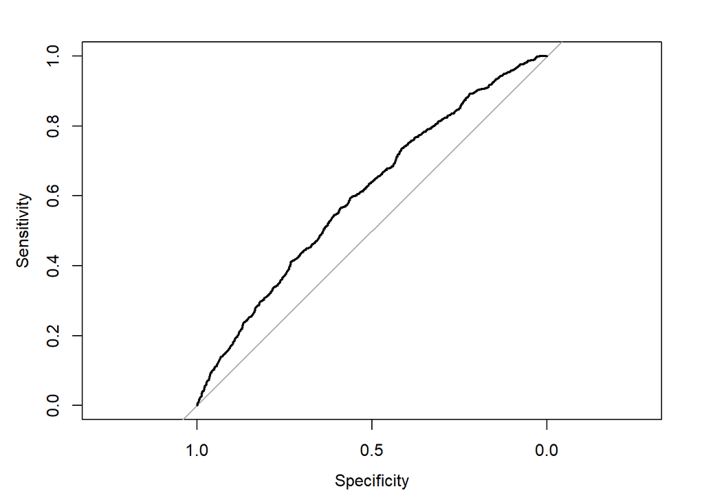

```r
library(pROC)

roc_curve <- roc(test$Arrest, prob)
plot(roc_curve)
```

```r
auc(roc_curve)
```

```
## Area under the curve: 0.6052
```

The model achieved an AUC of approximately 0.61, indicating weak but better-than-random classification performance.

This suggests that the model does capture some underlying signal in the data. However, this signal is not strong enough to produce reliable predictions at practical classification thresholds.

## **Model Limitations**

The poor performance is likely due to:

- The data is imbalanced, with far fewer arrest cases than non-arrest cases
- The variables used (age, sex, descent, and area) may not be strong predictors of whether an arrest happens
- Some categories have very few observations, which makes it harder for the model to learn reliable patterns.

Because of this, the model has difficulty correctly identifying arrest cases.

# **Conclusion**

This project demonstrates a full data analysis process using real-world crime data.

While the exploratory analysis showed some interesting patterns, the predictive model did not perform well. In particular, it struggled to accurately identify arrest cases, and its performance was sensitive to the classification threshold.

This highlights how accuracy alone can be misleading, especially when the data is imbalanced.

In the future, the model could be improved by:

- adding more relevant features
- trying different ways to handle the imbalance
- testing other types of models

Overall, this project shows the importance of carefully evaluating model performance and understanding its limitations.